# Module 6 Lecture - Learning

Introductory Psychology

Quinton Quagliano, M.S., C.S.P

Department of Psychology

# 1 Overview and Introduction

Agenda

1 Overview and Introduction

2 What is Learning

3 Classical Conditioning

4 Operant Conditioning

5 Observational Learning (Modeling)

6 Conclusion

## 1.1 Textbook Learning Objectives

- Explain how learned behaviors are different from instincts and reflexes
- Define learning
- Recognize and define three basic forms of learning—classical conditioning, operant conditioning, and observational learning
- Explain how classical conditioning occurs
- Summarize the processes of acquisition, extinction, spontaneous recovery, generalization, and discrimination
- Define operant conditioning
- Explain the difference between reinforcement and punishment
- Distinguish between reinforcement schedules
- Define observational learning
- Discuss the steps in the modeling process
- Explain the prosocial and antisocial effects of observational learning

## 1.2 Instructor Learning Objectives

- Be able to discriminate between the 3 forms of learning given a detailed example
- Be able to connect learning back to the historical paradigm of behaviorism
- Be able to describe the process and nuances of each of the 3 types of learning

## 1.3 Introduction

- **Important: The ideas you learn in this lecture are relevant to how you learn in class! It might be worth introspecting on the basis of thinking about how these things relate to your behaviors as a student.**
- **Question: Which of the historical perspectives on psychology was/is especially interested in examining objective measurements of observable actions?**
- A) Behaviorism
- B) Structuralism
- C) Psychoanalysis
- D) Cognitivism
- Some skills and behaviors are **innate**, or something that we don't have to be taught
- Other skills and behaviors we pick up as we live through different experiences, as we **learn**
- **Important: From the moment we are born into the world, to the moment we die, we are learning! Today, we will *learn* (pun intended) about how some of that works!**
- **Discuss: What is something you have learned how to do in your life? A certain sport? An instrument? Something else?**

# 2 What is Learning

Agenda

1 Overview and Introduction

2 What is Learning

3 Classical Conditioning

4 Operant Conditioning

5 Observational Learning (Modeling)

6 Conclusion

## 2.1 Introduction

- As said before, not all behaviors we do need to be learned,
  - E.g., a young baby (of any mammalian species) will naturally suckle for early nourishment from it’s mother, fish are (mostly) born knowing how to swim (albeit, not well), a giraffe is going to figure out how to walk right away (albeit poorly at first)
- **Important: Even though we focus a lot on humans in this class, this unit does apply readily to other species as well! In fact, a lot of behavioral research is done on animals**

## 2.2 Unlearned Behaviors

- Those skills and behaviors that are not learned are called **unlearned behaviors** (duh), and they come in two types: reflexes and instincts
- **Reflexes** are muscle or neuronal actions that occur due to specific environmental stimuli
  - Tend to be more basic physiological reactions, not complex behaviors
  - E.g., knee jerk reflex at the doctors office from hitting directly beneath the patella (kneecap) bone, our pupil dilating, etc.
- **Question: Review: What part of the eye contains the muscles that control the size of the pupil?**
- A) Retina
- B) Lens
- C) Cornea
- D) Iris
- **Question: We discussed reflexes briefly in Module 3, what part of the CNS is generally responsible for reflexes?**
- A) Thalamus
- B) Sensory receptors
- C) The Spine
- D) Afferent neurons
- **Instincts** are behaviors that are more complex and deal with reaction toward broad arrays of situations and environments
  - Like reflexes, instincts are still part of us as unlearned behaviors
  - E.g., sexual drive increase and tendencies during puberty, migration of birds south for the winter, etc.
- Reflexes and instincts are adaptive, or help us survive - without many of these, we would be less likely to survive
  - However, they are not necessarily fully developed at birth, these reflexes and instincts might later become apparent we grow and develop
- **Discuss: What historical perspective and modern subfield of psychology are most concerned with this 'adaptation for survival'?**
- **Discuss: What other human reflexes and instincts can you think of outside of the examples above?**

## 2.3 Learned Behaviors

- Not all behaviors we develop without any intervention, like the unlearned behaviors from before
- **Learned behaviors or learning** is a change in behavior or cognition that results from experiences
  - This process may be relative fast or slow, depending on the complexity of the behavior to learn
  - As you’ll learn during this unit, there’s also several ways to explain the process of learning
- **Question: Which of the following strikes you as a skill you are likely to learn relatively quickly?**
- A) Mastering a Beethoven song on the piano
- B) Learning how to jump shot from the 3-point line in basketball
- C) Learning how to write in cursive
- D) Learning how to use a stapler
- **Important: Unsurprisingly, what you are learning in this class, and in college in general, is a slow process due to its complexity!**
- Much learning that we do can be connected to **associative learning**, or the process that we take when we connect two stimuli or events together in our mind because of how they occur together in time and space
  - But, the exact way this happens is best described through two types of conditioning: classical and operant
  - Late we’ll touch on a third that functions not on associations, but on observation

## 2.4 Preview of Types of Conditioning

- **Classical conditioning or Pavlovian conditioning** is an unconscious association between two events, hinging on reflexive reactions
  - E.g., we notice lightning is always accompanied by thunder, so we associate the light of the lightning with the loud audible boom of the thunder
- **Discuss: In module 1, we very briefly discussed the contributions of Ivan Pavlov - what were his famous studies done on?**
- **Operant conditioning** also involves association, but instead connects a certain behavior to a punishment and/or a reinforcement, reducing or enhancing that behavior, respectively
- **Observational learning** is often additive to both classical and operant conditioning, and involves learning by watching others
- The three terms are all connected to behaviorism, though there are other theories and processes of learning out there.

# 3 Classical Conditioning

Agenda

1 Overview and Introduction

2 What is Learning

3 Classical Conditioning

4 Operant Conditioning

5 Observational Learning (Modeling)

6 Conclusion

## 3.1 Introduction

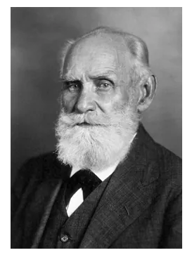

- Classical conditioning was first explored formally by Russian scientist Ivan Pavlov - but he was a physiologist, not a psychologist!
  - In his dogs, we was first interested in the dogs’ digestion, not their behavior
- **Question: Pavlov first came to his conclusions by making observations and then creating hypothesis based on those conclusions. From module 2, we would call this [blank] reasoning**
- A) Intuitive
- B) Deductive
- C) Inductive
- D) Authoritative
- Pavlov general determined the two categories of learned and unlearned behaviors

## 3.2 Unconditioned Stimuli and Responses

- In the Pavlovian example of dogs salivating as they were presented with food:
  - The **unconditioned stimulus (UCS)** that elicits a reflex is the food presented to the dog
  - The **unconditioned response (UCR)** is the reflex or unlearned response to that UCS
  - Then, before any conditioning or learning: $UCS \rightarrow UCR$

## 3.3 Conditioned Stimuli and Responses

- To classically condition: a **neutral stimulus (NS)**, that does not naturally elicit a UCR, is added alongside the UCS
  - I.e., $NS \neq UCS$ as it lacks a natural, reflexive response
  - During the conditioning process, our behavior equation now looks like this $NS + UCS \rightarrow UCR$
- Over many repetitions the UCS is removed, the NS becomes a **conditioned stimulus (CS)**, and the resulting behavior is now known as a **conditioned response (CR)**
  - Thus, now the behavior equation looks like: $CS \rightarrow CR$
- **Important: The distinction between the different types of stimulus and responses is important! Remember these acronyms.**

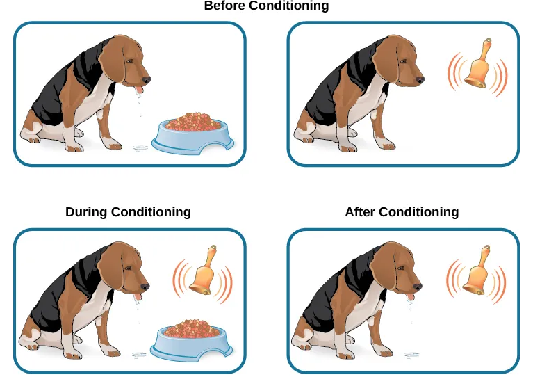

## 3.4 General Processes in Classical Conditioning

- **Important: Below is some important vocabulary used specific to classic conditioning.**
- During the “learning period” or **acquisition**, the subject learns to associate the neutral stimulus with the unconditioned stimulus and unconditioned response - eventually leads to the development of the conditioned stimulus and condition response
- **Discuss: Write out the 'equations' for these two stages using the acronyms introduced earlier**
- However, not all associations between the conditioned stimulus remain permanent
  - Gradually, and over time, the weakening of the CS (in isolation, away from the UCS) to elicit a CR is called **extinction**
  - What is happening here is basically that the CS is simply becoming insufficiently associated with the original reflexive stimulus
  - BUT, if some time passes, and the CS return and once again begins eliciting the CR, there may be **spontaneous recovery**, but even this will eventually involve a degree of extinction

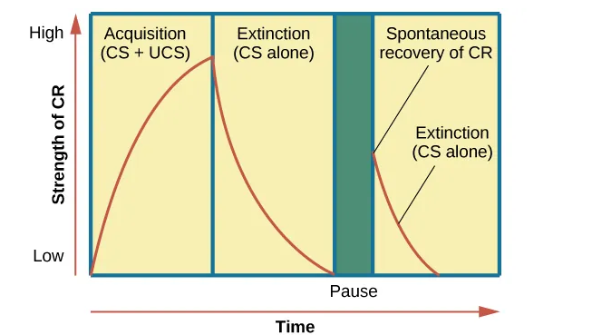

- **Important: Think of acquisition as the strengthening of an association, and extinction as a weakening**
- On top of the other nuances, not all similar stimuli to the CS are sufficient to elicit the same CR
  - When a similar, but different stimulus to the CS does not produce a CR, then the subject is unconsciously performing **stimulus discrimination**
  - When the organism responds to similar stimulus with the CR, then they are said to be doing **stimulus generalization**

## 3.5 Behaviorism

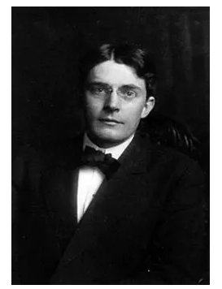

- The formal term of “behaviorism” was first coined by John B. Watson, who had a strong belief that behaviors that we see in humans are mostly resulting from conditioned responses
  - He extended Pavlov’s ideas, which were mostly relegated to dogs, and brought that to people
- **Discuss: Behaviorism was reactionary to earlier historical perspectives, and tried to reject their notions; explain how behaviorism rejects the views of psychoanalysis**
- **Important: Some people in the behaviorist camp genuinely believe that most of human behavior is explainable by the concepts in this module!**
- Watson and Rosalie Rayner performed experiments, trying to elicit a phobia in a small child nicknamed “Little Albert”
  - If all human behavior was genuinely the result of these learned associations, then creating these associations in Albert should be sufficient to create longstanding fear
- **Question: What is a crucial difference between an experiment and a purely correlational study?**
- A) Experiments have independent variables, correlational do not
- B) Experiments provide weaker evidence and claims than correlational studies
- C) Experiments are more generalizable than correlational studies
- D) Experiments are just a different name for correlational studies

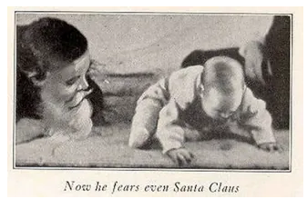

- Little Albert was first exposed to non-scary, fuzzy neutral stimuli (NS): cotton wool, white rats, a dog, a rabbit, etc. and produced no negative response
  - Then Watson began to make a loud noise every time Albert interacted with them - the loud noise (UCS) instinctively causing little Albert to become scared and cry (UCR)
  - Through acquisition Albert eventually became afraid (CR) of the things he once enjoyed e.g., the dog (CS)
  - He even began to stimulus generalize, associating a Santa Claus mask
- **Question: In the modern day, Watson and his team would have to go through a regulatory body at their university to get their ethical plan approved for the Little Albert study, what would that be called?**
- A) IACUC
- B) NIH
- C) CRC
- D) IRB
- **Discuss: Eventually, Little Albert no longer showed this fear response like he initially did, and did not have any long-lasting phobia - what would we call this weakening of association?**

# 4 Operant Conditioning

Agenda

1 Overview and Introduction

2 What is Learning

3 Classical Conditioning

4 Operant Conditioning

5 Observational Learning (Modeling)

6 Conclusion

## 4.1 Introduction

- Now we will switch to **operant conditioning**, which, while still related to learning deals with a different set of reasons why learning occurs
- The primary focus of operant conditioning is that it focuses mostly on consequences

## 4.2 Separating Operant and Classical Conditioning

- Operant conditioning was partially proposed because some felt that classical conditioning was limited in that there first had to be some reflexive UCS and UCR, but that it provided no explanation for behaviors and stimuli that had no reflexive root

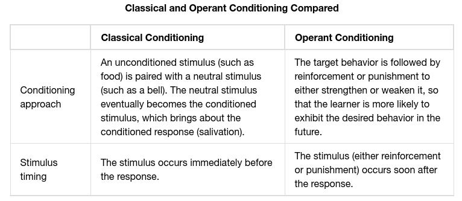

- B.F. Skinner and Edward Thorndike focused on the **law of effect**, which said that organisms behaviors and tendency towards those same behaviors in the future is determined by the consequences of reinforcement and punishment

## 4.3 Reinforcement and Punishment Overview

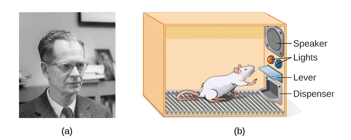

- Reinforcements and punishments are the two types of consequences that can be had after a behavior is performed
- **Important: "Reinforcement" and "Punishment", along with "Negative" and "Positive" have specialized meanings in operant conditioning, be careful with how you use them**

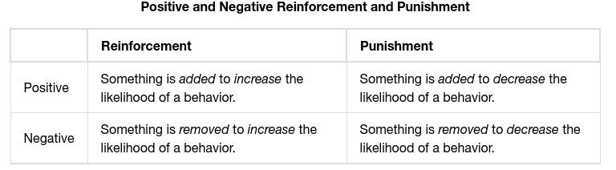

- **Question: After a person speaks out of turn during an important meeting, they are temporarily shut out of future meetings, thus making them less likely to speak out of turn again - which consequence type is this?**
- A) Positive Reinforcement
- B) Negative Reinforcement
- C) Positive Punishment
- D) Negative Punishment

## 4.4 Reinforcement Examples

- **Important: Generally, reinforcement is viewed be the 'better' approach for encouraging most behaviors**
- **Reinforcement** always has the intention to encourage or continue the behavior
- Thus, **Positive Reinforcement** is adding a desirable reward or stimulus to encourage behavior
  - E.g., Skittles in the textbook example
- **Negative Reinforcement** is removing an undesirable condition to encourage certain behaviors
  - E.g., Car seatbelt alarm example

## 4.5 Punishment Examples

- **Punishment** always has the intention to discourage or discontinue the behavior
- **Positive Punishments** are adding some undesirable stimulus to discourage behavior
  - E.g., After knocking a toothbrush off the counter, a cat is stray with what by its owner
- **Negative Punishments** are removing some desired thing to discourage behavior
  - E.g., A person is removed from class for cheating or being disruptive
- **Important: I like to think of it like math: positive (+) is adding stuff, negative (-) is subtracting/removing stuff**
- **Question: A child, in the process of potty training, is verbally praised by their father for successfully using the toilet**
- A) Positive Reinforcement
- B) Negative Reinforcement
- C) Positive Punishment
- D) Negative Punishment

## 4.6 Shaping

- **Shaping** (I sometimes think of it as stepping) is used to reward or reinforce small, sequential behaviors as part of a larger process
  - This is often done for complex behaviors, as organisms are rarely going to fully succeed in a complex, extended process on the first time
  - So you reward as they complete individual steps
  - As time goes on, you only continue to reward farther steps in the process
- Example from the book:

> Let’s consider parents whose goal is to have their child learn to clean his room. They use shaping to help him master steps toward the goal. Instead of performing the entire task, they set up these steps and reinforce each step. First, he cleans up one toy. Second, he cleans up five toys. Third, he chooses whether to pick up ten toys or put his books and clothes away. Fourth, he cleans up everything except two toys. Finally, he cleans his entire room.

## 4.7 Primary and Secondary Reinforcers

- What reward a person or animal is reinforced with plays a large role in whether the reinforcement will be adequate to encourage behavior
  - I.e., an insufficient reward won’t actually encourage behavior!
- We think of reinforcers as being either primary or secondary:
  - **Primary reinforcers** are those that have an innate appeal to us
    - E.g., Water, food, sleep, shelter, sex, physiological pleasure, social connection, etc.
  - **Secondary reinforcers** are those that have qualities that indirectly lead to primary reinforcers
    - E.g., Money, verbal praise, stickers
  - Thus, if a reward does not connect back to a primary need in some way, it has no value as a reinforcer
- **Important: Whether a reward is very effective or only a little has nothing to do with whether it is primary or secondary!**

## 4.8 Cognition and Latent Learning

- Skinner, with his intense focus on what is observable as a behavior and as a result of conditioning, is described as a **radical behaviorist.**
- However, other psychologists disagreed, and believed that some internal processes played a role
  - E.g. Tolman’s and his mice’s **cognitive map** and the demonstration of **latent learning**

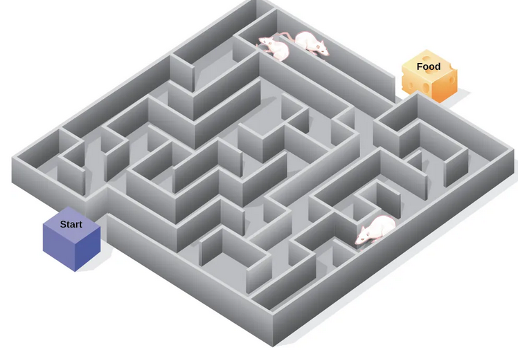

- **Question: Just like behaviorism was a reactionary perspective to those before it, which historical perspective was a reaction to behaviorism?**
- A) Psychoanalysis
- B) Functionalism
- C) Developmental Psychology
- D) Cognitivism

# 5 Observational Learning (Modeling)

Agenda

1 Overview and Introduction

2 What is Learning

3 Classical Conditioning

4 Operant Conditioning

5 Observational Learning (Modeling)

6 Conclusion

## 5.1 Introduction

- Both classical and operant conditioning can be thought of as forms of **associative learning**:
  - Classical involves association of conditioned stimuli (from neutral stimuli) and conditioned responses
  - Operant involves association of behaviors and consequences
- On the other hand, we have **observational learning**, which is where we learning by watching and imitating others
  - The people or things that we watch and learn from are called **models**
  - E.g., like learning good life skills from someone you consider a role model

[figure not shown]

- A fairly important psychologist in this area was Albert Bandura, who was often involved in studies surrounding children and their growth from one life stage to the next, and how that played into their behavior
- **Question: Based on that above description, which of the following classifications best fits Bandura's subfield?**
- A) Evolutionary
- B) Biopsychology
- C) Developmental
- D) Counseling
- Bandura’s idea of how modeling changes behavior focused on 3 core types of models:
  - **Live models,** who demonstrate and show a practice or behavior live and in-person - E.g., a yogi shows a yoga class how to perform a pose
  - **Verbal models,** who only describe how to perform a certain behavior or practice, a coach describes the process of throwing a baseball, going through the different positions of the arm
  - **Symbolic models,** who are real/fictional demonstrate behaviors (like live models), but through media, books, video games, etc. - like a motivational video of an athlete practicing an action in their sport over and over again

## 5.2 Steps in the Modeling Process

- **Important: Modeling and observational learning are thought to be much more complex and internal than classical and operant**
- Much like with several pre-requisites for classical and operant learning, modeling requires some specific components to really “work”
- The following are the steps for modelling to work, in Bandura’s view
- First, you must attend, or pay attention, to what the model is doing/saying
- **Discuss: In Module 5, we discussed that attention was a pre-requisite to actually perceive something after sensing it - what were the other two things that could modify whether senses resulted in conscious perception?**
- Second, you must retain and remember what you observed and paid attention to, this is called **retention**
- Third, you must be able to replicate the action shown/described by the model, called **reproduction**
- Finally, you must have the necessary motivation to copy the behavior; without this, you will have no internal incentive to continue to behavior

## 5.3 Nuances and Modification to the Modeling Process

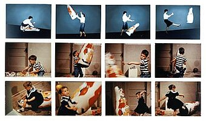

# 6 Conclusion

Agenda

1 Overview and Introduction

2 What is Learning

3 Classical Conditioning

4 Operant Conditioning

5 Observational Learning (Modeling)

6 Conclusion

## 6.1 Recap

- The three frameworks for understanding learning from primarily a behaviorist perspective: classical, operant, and observation - provide different but also complementing ideas on how we learn behaviors and change our existing ones. But, you may encounter other theories of learning during college as well!
- There are many complexities that contribute to whether we learn and change - our motivation, attention, external/internal reinforcements and punishments.
- Several classic studies by psychologists like Bandura, Skinner, Watson, etc., help demonstrate some of the basic ideas of all three behavioral learning frameworks

## 6.2 Lecture Check-in

- Make sure to complete and submit the lecture check-in

[figure not shown]

Module 6 Lecture - Learning || Introductory Psychology